# Julia

[figure not shown]

#### What is Julia and why should I care? What is Julia good at?

- An exciting new language made specifically for scientific computing
- Interpreted (like Matlab/Python), but also (JIT-)compiled
- Easy to learn, write, and maintain, but designed with performance in mind (2-3x C speed)
  - Define functions wherever you want
  - Functions with optional, keyword, defualt arugments
  - Organize code in modules/packages
- Core concept is multiple dispatch -- specialize function behavior based on types of *all* arguments (more later)
- Parallel programming features built into the language - easy and inexpensive scalability (more later)
- Most of base Julia is written in Julia itself
  - User code is set on "same level" as language and library code
  - With smart algorithms, will have same performance as the language itself
  - If you know Julia, you can look at source and see how the language itself is implemented

## Multiple Dispatch

- Julia has an advanced expressive type system
- ... but you can only think about it when you want
- Functions are applied by matching function name and types of arguments
- The most specific match possible is called
- Consider a contrived example that demonstrates the concept

```python
f(a::Any, b) = "fallback"
f(a::Number, b::Number) = "a and b are both numbers"
f(a::Number, b) = "a is a number"
f(a, b::Number) = "b is a number"
f(a::Integer, b::Integer) = "a and b are both integers"
```

```
f (generic function with 5 methods)
```

```python
f(randn(4, 4), "foo")
```

```
"fallback"
```

```python
f(1, 1.0)
```

```
"a and b are both numbers"
```

```python
f(1.0, "foo")
```

```
"a is a number"
```

```python
f("foo", 1)
```

```
"b is a number"
```

```python
f(1, 2)
```

```
"a and b are both integers"
```

## Parallel Computing

- Building blocks for parallel computaiton are built in to the language
  - Ability to programmatically start additional local or remote processes (`addprocs`)
  - Operate on distributed arrays (`DArray`)
  - Shared memory arrays for local processes (`SharedArray`)
  - Parallel `for` loops and `map`
- Easy and free to install in the cloud (`AWS.jl`, `GCloud.jl`)

### `@parallel for`

- Suppose we wanted to simulate the number of heads in `n` coinflips
- We might write the following function:

```python
function count_heads(n)
    c::Int = 0
    for i=1:n
        c += randbool()
    end
    c
end

count_heads(10)  # warm up compiler
@timeit count_heads(50000000)  # run timing
```

```
1 loops, best of 3: 163.64 ms per loop
```

- Now consider the equivalent parallel version of this function:

```python
function count_heads_par(n)
    @parallel (+) for i=1:n
        int(randbool())
    end
end

addprocs(5)  # add five local processes
count_heads_par(10)  # warm up compiler
@timeit count_heads_par(50000000)  # run timing
```

```
10 loops, best of 3: 41.80 ms per loop
```

### Case study: solving models in QuantEcon.jl

- The QuantEcon.jl library has a number of classic Macroeconomic models
- Most have these common functions defined:
  - `bellman_operator`: perform one iteration of natural operator defined by the Bellman equation
  - `init_values`: produce initial values for discretized value function
- These building blocks suggest a common (if naive) algorithm for solving a model
  - Compute initial guess for value function from `init_values`
  - Iterate on `bellman_operator` until you reach a fixed point
- In code this looks like

```python
function solve_vf(m::AbstractModel)
    init = init_values(m)
    f(x) = bellman_operator(m, x)
    return compute_fixed_point(f, init)
end
```

- *If* we happen to know a better routine for solving a specific model, we can implement it as a special case

```python
@everywhere using QuantEcon, QuantEcon.Models

c = CareerWorkerProblem() # (Neal, 1999)
ifp = ConsumerProblem()   # income fluctuation problem -- many refs
jv = JvWorker()           # (Jovanovic, 1979)
odu = SearchProblem()     # (Ljungqvist and Sargent, 2012)
gm = GrowthModel()        # standard growth model -- many refs

models = [c, ifp, jv, odu, gm];
```

```python
for m in models
    println(@which solve_vf(m))
end
```

```
solve_vf(m::AbstractModel) at /Users/sglyon/.julia/v0.3/QuantEcon/src/Models.jl:26
solve_vf(m::ConsumerProblem) at /Users/sglyon/.julia/v0.3/QuantEcon/src/models/ifp.jl:169
solve_vf(m::AbstractModel) at /Users/sglyon/.julia/v0.3/QuantEcon/src/Models.jl:26
solve_vf(m::SearchProblem) at /Users/sglyon/.julia/v0.3/QuantEcon/src/models/odu.jl:160
solve_vf(m::AbstractModel) at /Users/sglyon/.julia/v0.3/QuantEcon/src/Models.jl:26
```

```python
# Run through one iteration of each to warm up compiler
map(m -> solve_vf(m, verbose=false, err_tol=Inf), models);

# solve in serial
@time map(m -> solve_vf(m, verbose=false, max_iter=1000), models);
```

```
elapsed time: 18.388185546 seconds (3690426212 bytes allocated, 15.27% gc time)
```

```python
# do the same in parallel
pmap(m -> solve_vf(m, verbose=false, err_tol=Inf), models);
@time pmap(m -> solve_vf(m, verbose=false, max_iter=1000), models);
```

```
elapsed time: 10.527034168 seconds (121344 bytes allocated)
```

- Not quite 5 times faster... why?
- Some models take longer to solve than others. So some processes finished long before 10 seconds, but had to wait for others
- Suppose we wanted to solve the Ljungqvist and Sargent search with unknown offer distribution model for agents of various discount factors...
- Easy!

```python
odu_mods = [SearchProblem(bet=i) for i in linspace(0.9, 0.99, 500)];
@time results = pmap(m -> solve_vf(m, verbose=false, max_iter=1000), odu_mods);
```

```
elapsed time: 1.736679092 seconds (8555848 bytes allocated)
```

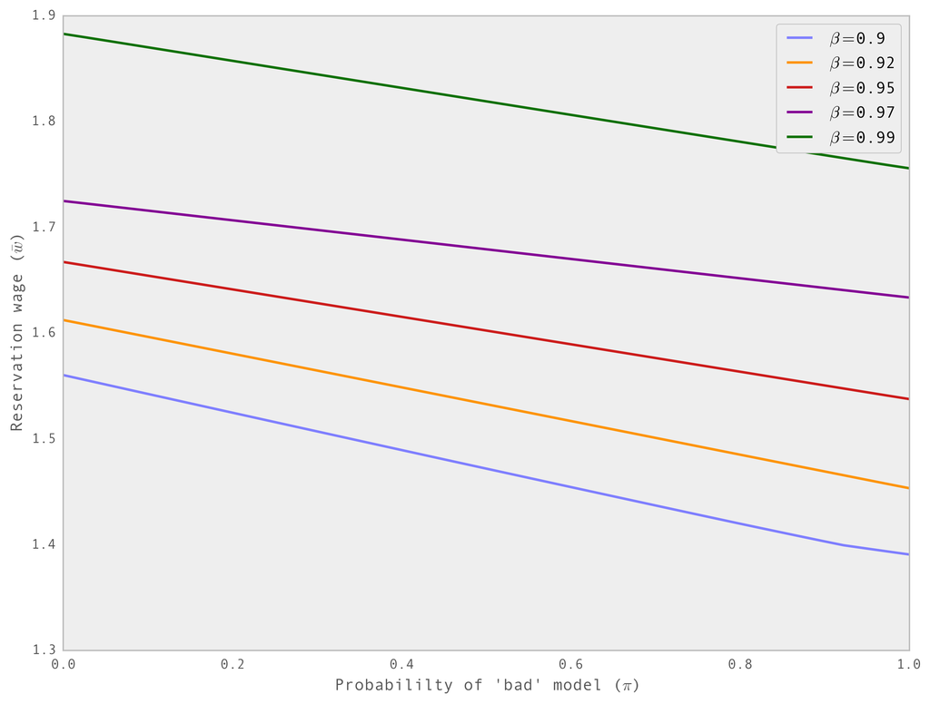

```python
using PyPlot

function plot_results(results, odu_mods, n=5)
    n_res = size(results, 1)
    inds = int(linspace(1, n_res, n))
    fig, ax = subplots()
    for i in inds
        mod = odu_mods[i]
        bet = round(mod.bet, 2)
        pi_grid = mod.pi_grid
        ax[:plot](pi_grid, results[i], label=L"$\beta=$"*"$bet")
    end
    ax[:set_xlabel](L"Probabililty of 'bad' model ($\pi$)")
    ax[:set_ylabel](L"Reservation wage ($\bar{w}$)")
    ax[:legend]()
    nothing
end

plot_results(results, odu_mods);
```